# Part I - Ford GoBike Data Exploration

## Preliminary Wrangling

```python
# import all packages and set plots to be embedded inline
import numpy as np
import pandas as pd
import matplotlib.pyplot as plt
import seaborn as sb
import datetime as dt

%matplotlib inline
```

```python
# we load in the dataset into a pandas dataframe
tripdata = pd.read_csv('201902-fordgobike-tripdata.csv')
```

```python
# we take a preliminary look at the dataset
tripdata.head(10)
```

[output not shown]

```python
# printing data general infos
print(tripdata.info())
```

```
<class 'pandas.core.frame.DataFrame'>
RangeIndex: 183412 entries, 0 to 183411
Data columns (total 16 columns):
 #   Column                   Non-Null Count   Dtype
---  ------                   --------------   -----
 0   duration_sec             183412 non-null  int64
 1   start_time               183412 non-null  object
 2   end_time                 183412 non-null  object
 3   start_station_id         183215 non-null  float64
 4   start_station_name       183215 non-null  object
 5   start_station_latitude   183412 non-null  float64
 6   start_station_longitude  183412 non-null  float64
 7   end_station_id           183215 non-null  float64
 8   end_station_name         183215 non-null  object
 9   end_station_latitude     183412 non-null  float64
 10  end_station_longitude    183412 non-null  float64
 11  bike_id                  183412 non-null  int64
 12  user_type                183412 non-null  object
 13  member_birth_year        175147 non-null  float64
 14  member_gender            175147 non-null  object
 15  bike_share_for_all_trip  183412 non-null  object
dtypes: float64(7), int64(2), object(7)
memory usage: 22.4+ MB
None
```

```python
# we drop rows with missing values then we check the dataset rows
tripdata.dropna(inplace=True)
tripdata.isnull().any().sum()
```

```
0
```

```python
# checking the number of unique values in each column
tripdata.nunique()
```

```
duration_sec                 4429
start_time                 174941
end_time                   174939
start_station_id              329
start_station_name            329
start_station_latitude        329
start_station_longitude       329
end_station_id                329
end_station_name              329
end_station_latitude          329
end_station_longitude         329
bike_id                      4607
user_type                       2
member_birth_year              75
member_gender                   3
bike_share_for_all_trip         2
dtype: int64
```

```python
# converting start_time and end_time to datetime instead of strings
tripdata['start_time'] = pd.to_datetime(tripdata['start_time'])
tripdata['end_time'] = pd.to_datetime(tripdata['end_time'])
```

```python
# extracting the start day and month from start_time and stocking them  in new columns
tripdata['start_hour'] = tripdata['start_time'].dt.strftime("%H")
tripdata['start_day'] = tripdata['start_time'].dt.day_name()

# extracting the end day and month from end_time and stocking them  in new columns
tripdata['end_hour'] = tripdata['end_time'].dt.strftime("%H")
tripdata['end_day'] = tripdata['end_time'].dt.day_name()
```

```python
# the final dataset shape
print(tripdata.shape)
```

```
(174952, 20)
```

### What is/are the main feature(s) of interest in your dataset?

> I am most intersted in discovering the distribution form of trips duration(in seconds), and figuring out the most occupied trip times or the time with highest number of trips in hours of the day (24 hours) and in days of the week (7 days), as well as the type of the relationship between the duration and the other predictor variables namely starting days, the user type and gender.

### What features in the dataset do you think will help support your investigation into your feature(s) of interest?

> I expect that the most trips are taken in the early morning hours and in weekends. As for the effect of some predictor variables on the duration, I predict that some factors like gender and user type will reflect different impacts (to discover) on the duration of the trip.

## Univariate Exploration

### The distribution of trip duration in seconds

We will start by looking at the distribution of the quantitative variable of interest: duration_sec by using histograms.

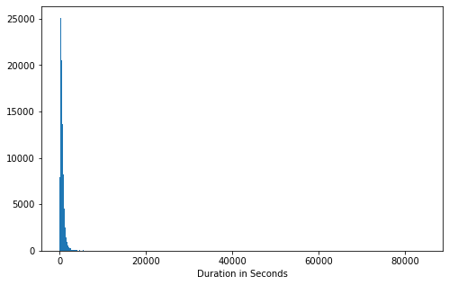

```python
# we start with a standard scale plot and we define plot_hist function to reuse it later
def plot_hist(binsize = 100, binstart = tripdata['duration_sec'].min()):
    bins = np.arange(binstart, tripdata['duration_sec'].max() + binsize , binsize)
    plt.figure(figsize=[8, 5])
    plt.hist(data = tripdata, x = 'duration_sec', bins = bins)
    plt.xlabel('Duration in Seconds')
plot_hist();
```

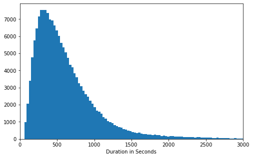

```python
# we notice that the vast majority of values have a duration less than 3000 seconds, hence we set the first interval [0, 3000]
plot_hist(30)
plt.xlim([0, 3000]);
```

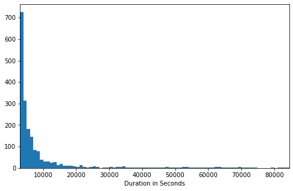

```python
# then we plot values of the remaining interval [3000, tripdata['duration_sec'].max()]
plot_hist(binsize = 1000, binstart = 3000)
plt.xlim([3000, tripdata['duration_sec'].max()]);
```

We notice that there's a long tail in the distribution for the second interval values, which means there is a significant amount of data not shown properly with the normal scale, thus we will use the log scale since it will give us a more clair idea about the distribution of trip durations.

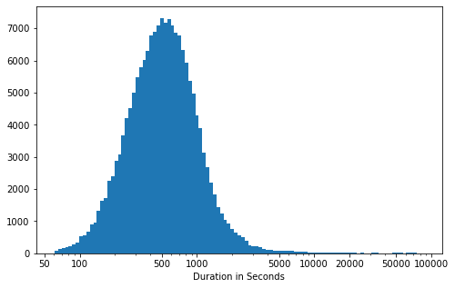

```python
# we use the logarithm scale through xscale and we set appropriate bins and binsize
binsize = 0.03
bins = 10 ** np.arange(np.log10(tripdata['duration_sec'].min()), np.log10(tripdata['duration_sec'].max()) + binsize, binsize)
plt.figure(figsize=[8, 5])
plt.hist(data = tripdata, x = 'duration_sec', bins=bins)
plt.xscale('log')
plt.xticks([50, 1e2, 5e2, 1e3, 5e3, 1e4, 2e4, 5e4, 1e5], [50, '100', '500', '1000', '5000', '10000', '20000', '50000', '100000'])
plt.xlabel('Duration in Seconds');
```

```python
# we check the mean of the distribution arithmetically
tripdata.duration_sec.mean()
```

```
704.0027436096758
```

Therefore the trip duration has a lognormal distribution, with the majority of trips have a short duration as they are distributed between 200 and 1000 seconds, with a mean near to 500 seconds (which is actually 704 seconds), and few long trip durations.

### The total number of trips per day and hour

Now we are going to discover the total number of trips each day of the week in both starting day and ending day, hence we use both ordinal categorical variables start_day and end_day, then we plot them using diagrams.

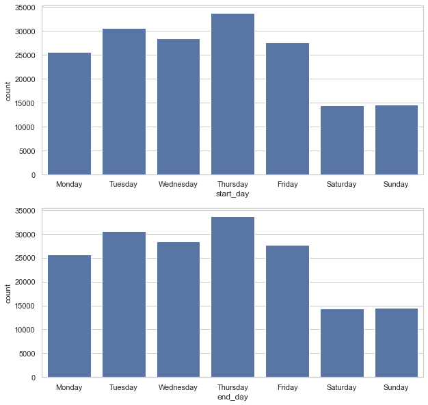

```python
# we plot our diagrams in days order using countplot order parameter
days = ['Monday', 'Tuesday', 'Wednesday', 'Thursday', 'Friday', 'Saturday', 'Sunday']
def plot_diag(s1, s2 ,size = [10,10], order = days):
    sb.set_theme(style="whitegrid")
    fig, ax = plt.subplots(2, figsize = size)
    color = sb.color_palette()[0]
    sb.countplot(data = tripdata, x = s1, order=order, color=color, ax = ax[0])
    sb.countplot(data = tripdata, x = s2, order=order, color=color, ax = ax[1]);
plot_diag('start_day', 'end_day')
```

As we see the most occupied day in the week is thursday with a total of more than 30000 trips in both start and end day, followed by tuesday, we notice also that the number of trips in all days is greater than 25000 except the weekends since they have the lowest total number of trips taken (under 15000) which is the opposite of what I was expecting!

Next we do the same process to find the total number of trips each hour of the day by calling the two ordinal variables start_hour and end_hour.

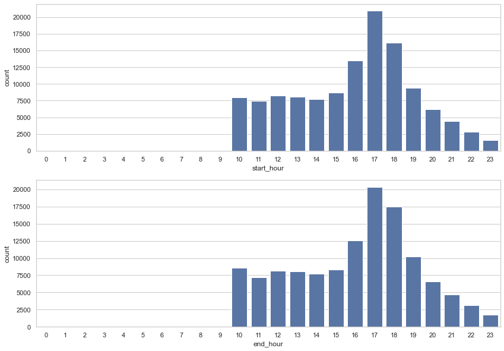

```python
# we plot the diagrams in hours order
hours = [str(i) for i in range(24)]
plot_diag('start_hour', 'end_hour', size = [14,10] ,order = hours)
```

### The total number of trips frequency per user type and gender

We could also determine the total number of trips frequency per user type and gender by using the nominal categorical variables user_type and member_gender, user has two possible values: customer or subscriber, and gender has three: male, female and other.

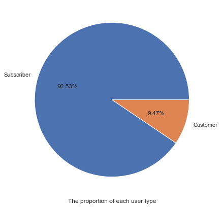

```python
# the frequency per user type
freq = tripdata['user_type'].value_counts()
freq.plot(kind = 'pie', autopct='%1.2f%%', figsize=[7,7], ylabel='');
plt.xlabel('The proportion of each user type');
```

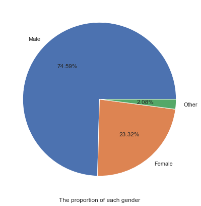

```python
# the frequency per gender
freq = tripdata['member_gender'].value_counts()
freq.plot(kind = 'pie', autopct='%1.2f%%', figsize=[7,7], ylabel='');
plt.xlabel('The proportion of each gender');
```

We could easily notice that 90% of users are subscribers, and approximately 75% of users are men.

### Discuss the distribution(s) of your variable(s) of interest. Were there any unusual points? Did you need to perform any transformations?

> The trip duration has a lognormal distribution, we notice first that in normal scale the distribution has a long tail to the right, thus we perform a scale transformation to obtain the log-scale.

### Of the features you investigated, were there any unusual distributions? Did you perform any operations on the data to tidy, adjust, or change the form of the data? If so, why did you do this?

> Yes, there was two unexpected outcomes: the first is the day when most trips taken was thursday followed by tuesday which was the opposite of my guess(weekends), the second was the hours when most trips are taken (17:00 and 18:00) but I expected they would be the early morning hours.

> We drop the missing values and we convert the start_time and end_time to datetime type in order to be able to extract the new variables we've created: start_day, end_day, start_hour and end_hour, because the source variables start_time and end_time have a lot of variables each, which is a break of the rule of tidiness: one variable possess one column.

## Bivariate Exploration

### The effect of the starting day on the duration of the trip

We explore the possible effect of the starting day of the week on duration time in seconds, since we study a qualitative vs quantitative variables, we use boxplots.

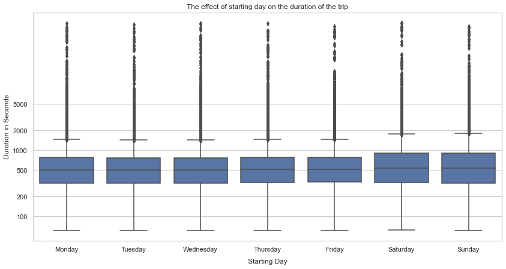

```python
# we plot our box plots by using boxplot, and not forgetting to chnge the scale of the numerical variable
plt.figure(figsize=[14,7])
sb.boxplot(data=tripdata,x = 'start_day',y='duration_sec',color=sb.color_palette()[0],order=days)
plt.yscale('log')
y_ticklocs=[100,200,500,1e3,2e3,5e3]
y_ticklabels=['100','200','500','1000','2000','5000']
plt.yticks(y_ticklocs,y_ticklabels)
plt.xlabel('Starting Day', labelpad=10)
plt.ylabel('Duration in Seconds')
plt.title('The effect of starting day on the duration of the trip');
```

### The effect of the user type on the duration of the trip

We do the same as above except this time we are intersted in the possible effect of the user type on duration of the trip.

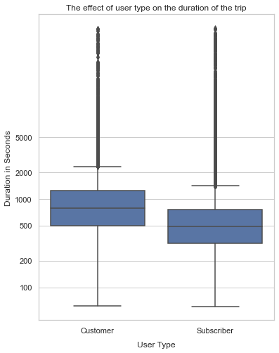

```python
# we define a function named box_plot to avoid repetition
def plot_box(x='user_type', xlabel='User Type', title='The effect of user type on the duration of the trip'):
    plt.figure(figsize=[6,8])
    sb.boxplot(data=tripdata,x = x,y='duration_sec',color=sb.color_palette()[0])
    plt.yscale('log')
    plt.yticks([100,200,500,1e3,2e3,5e3],['100','200','500','1000','2000','5000'])
    plt.xlabel(xlabel, labelpad=10)
    plt.ylabel('Duration in Seconds')
    plt.title('The effect of user type on the duration of the trip');
plot_box()
```

The above boxplots show us that customers take trips of long duration comparing to subscribers.

### The effect of the gender on the duration of the trip

Next we see the gender effect on the duration of the trip by using the same function created previously plot_box().

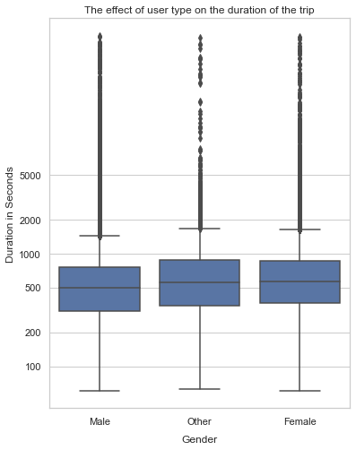

```python
# here we use the predefined function plot_box
plot_box(x='member_gender', xlabel='Gender', title='The effect of gender on the duration of the trip')
```

As we see from above boxplots, men have shorter trips comparing to othe genders.

### The relation between gender and user type

We investigate the relation between two qualitative variables: member_gender and user_type, we use clustered bar charts to see if there is a potential relationship.

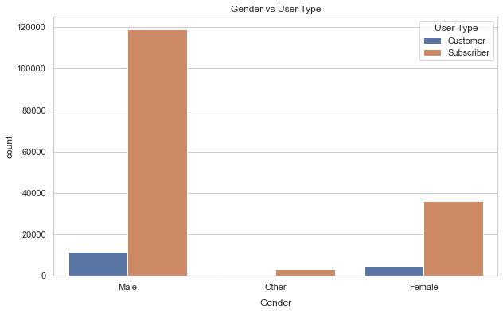

```python
# we plot the clustered bar charts by using the hue argument in countplot function
plt.rcParams['figure.figsize']=(10,6)
sb.countplot(data=tripdata,x='member_gender',hue='user_type')
plt.xlabel('Gender',labelpad=10)
plt.legend(title='User Type')
plt.title('Gender vs User Type');
```

We discover that there is no obvious relationship between gender and user type.

### The relation between starting day and user type

Now we move to explore the relationship between starting day and user type.

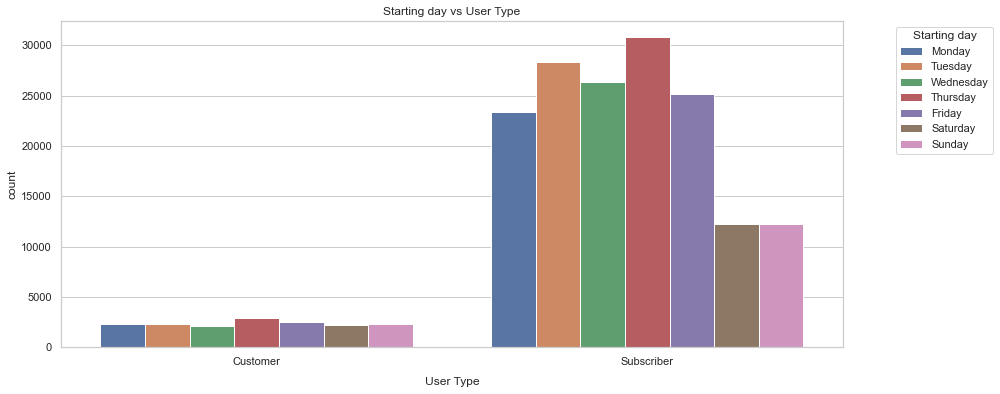

```python
# we define the function plot_clustered to reuse it later
def plot_clustered (x='user_type', hue='start_day', xlabel='User Type', legend='Starting day', title='Starting day vs User Type', data=tripdata):
    plt.rcParams['figure.figsize']=(14,6)
    sb.countplot(data=data,x=x, hue=hue, hue_order=days)
    plt.xlabel(xlabel,labelpad=10)
    plt.legend(title=legend, bbox_to_anchor=(1.2,1))
    plt.title(title);
plot_clustered()
```

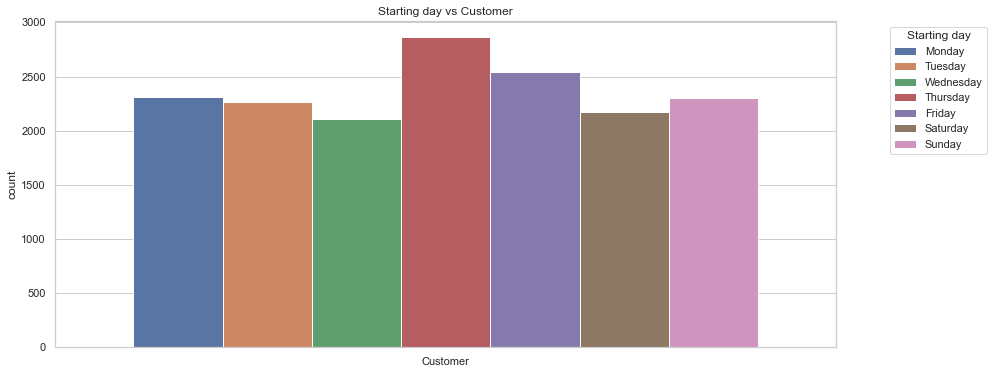

```python
# we take a closer look to customers' users' distribution
filtered_data = tripdata.query('user_type == "Customer"')
plot_clustered (x='user_type', hue='start_day', xlabel='', legend='Starting day', title='Starting day vs Customer', data=filtered_data)
```

Thursday remains the day (starting day) with most trips for both customers and subscribers, but among customers if we exclude thursday the number of trips each day of the week is between 2000 and 2600 trips(low dispersion), also the second day when most trips are taken is not tuesday, instead it is friday.

### The relation between starting day and gender

We close the bivariate study with a last exploration to the potential relation between starting day and gender

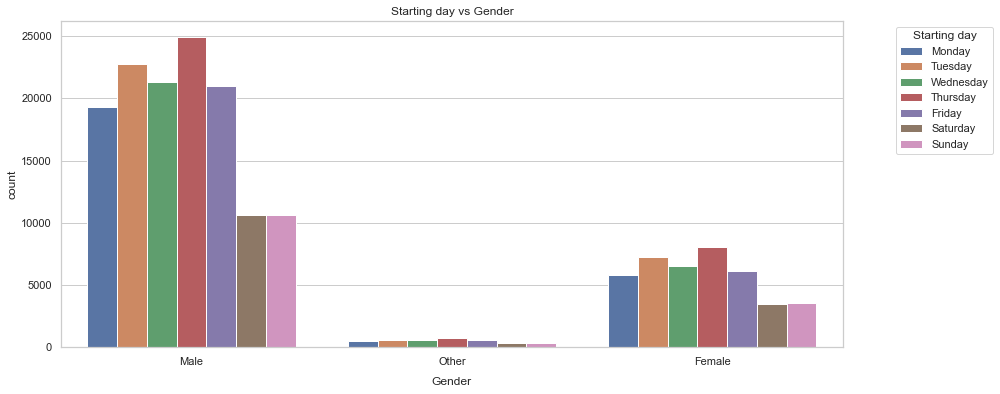

```python
# we use the predefined function plot_clustered by changing some arguments
plot_clustered (x='member_gender', hue='start_day', xlabel='Gender', legend='Starting day', title='Starting day vs Gender')
```

We could say that there is no particular relation between gender and starting day.

### Talk about some of the relationships you observed in this part of the investigation. How did the feature(s) of interest vary with other features in the dataset?

> We find that long trips occur on weekends more than other days, and customers trips are longer than subscribers trips, also men take shorter trips comparing to other genders.

### Did you observe any interesting relationships between the other features (not the main feature(s) of interest)?

> Among customers the number of trips each day excluding thursday is between 2000 and 2600 trips which means this ditribution has a low dispersion comparing to subscribers distribution, and the second day when most trips are taken is not tuesday instead it is friday. There is no apparent relationship between gender and user type, the same for gender and starting day.

## Multivariate Exploration

### The relation between duration, gender and user type

For the multivariate exploration, we explore one case study with two qualitative variables (gender and user type) and one quantitative variable: the duration by using an adapted violinplot.

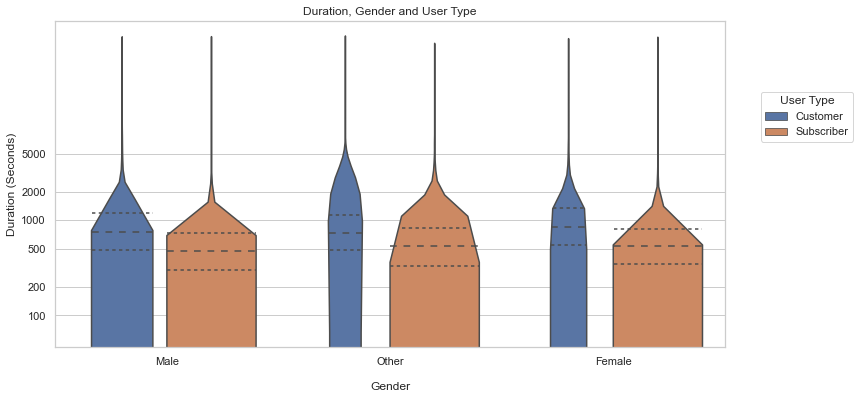

```python
# we use violin plot in this case
plt.figure(figsize=[12,6])
plt.yscale('log')
sb.violinplot(data=tripdata,x='member_gender',y='duration_sec',hue='user_type',inner='quartile')
plt.yticks([100,200,500,1e3,2e3,5e3],['100','200','500','1000','2000','5000'])
plt.xlabel('Gender', labelpad=15)
plt.ylabel('Duration (Seconds)')
plt.title('Duration, Gender and User Type')
plt.legend(title='User Type', bbox_to_anchor=(1.2,0.8));
```

We conclude that customers have the longest trip durations in all genders.

### Talk about some of the relationships you observed in this part of the investigation. Were there features that strengthened each other in terms of looking at your feature(s) of interest?

> We find that in all three genders, the subscribers take shorter trips in duration comparing to customers.

### Were there any interesting or surprising interactions between features?

> No, as we know the customer especially if it is his first time would usually take longer trip than a subscriber.